# R Beginners Course

## Downloading CHIRPSv2

Step 6: We will use the function *readHTMLTable* extracts data from HTML tables in an HTML document.

```r
df <- readHTMLTable(df)
head(df$indexlist)
##                          Name    Last modified Size Description
## 1                        <NA>             <NA> <NA>        <NA>
## 2            Parent Directory                     -
## 3  chirps-v2.0.1981.01.tif.gz 2015-01-30 03:33  14M
## 4  chirps-v2.0.1981.02.tif.gz 2015-01-30 04:30  14M
## 5  chirps-v2.0.1981.03.tif.gz 2015-01-30 05:32  14M
## 6  chirps-v2.0.1981.04.tif.gz 2015-01-30 06:50  14M
```

## Downloading CHIRPSv2

```r
class(df)
## [1] "list"
names(df)
## [1] "indexlist"
length(df)
## [1] 1
```

## Downloading CHIRPSv2

**Step 7:** The objective is to store the names of the files in an object, so we will keep only the first object from the df list.

```r
df <- df[[1]]
```

**Step 8:** We extract the object names from the data frame and just keep those that include “chirps” using the grep function.

```r
names <- df$Name
names <- names[grep("chirps", names)]
head(names)
## [1] "chirps-v2.0.1981.01.tif.gz" "chirps-v2.0.1981.02.tif.gz"
## [3] "chirps-v2.0.1981.03.tif.gz" "chirps-v2.0.1981.04.tif.gz"
## [5] "chirps-v2.0.1981.05.tif.gz" "chirps-v2.0.1981.06.tif.gz"
```

## Downloading CHIRPSv2

**Step 9:** Now, we can create the url of every element in the names vector.

```r
files <- file.path(path, names)
head(files)
## [1] "https://data.chc.ucsb.edu/products/CHIRPS-2.0/global_monthly/tifs//chirps-v2.0.1981.01.tif.gz"
## [2] "https://data.chc.ucsb.edu/products/CHIRPS-2.0/global_monthly/tifs//chirps-v2.0.1981.02.tif.gz"
## [3] "https://data.chc.ucsb.edu/products/CHIRPS-2.0/global_monthly/tifs//chirps-v2.0.1981.03.tif.gz"
## [4] "https://data.chc.ucsb.edu/products/CHIRPS-2.0/global_monthly/tifs//chirps-v2.0.1981.04.tif.gz"
## [5] "https://data.chc.ucsb.edu/products/CHIRPS-2.0/global_monthly/tifs//chirps-v2.0.1981.05.tif.gz"
## [6] "https://data.chc.ucsb.edu/products/CHIRPS-2.0/global_monthly/tifs//chirps-v2.0.1981.06.tif.gz"
```

## Downloading CHIRPSv2

**Step 10:** We can do something similar with the names of the output files and create the full path of each file.

```r
output_names <- file.path(output, basename(files))
head(output_names)
## [1] "C:/Users/Download_CHIRPS/chirps-v2.0.1981.01.tif.gz"
## [2] "C:/Users/Download_CHIRPS/chirps-v2.0.1981.02.tif.gz"
## [3] "C:/Users/Download_CHIRPS/chirps-v2.0.1981.03.tif.gz"
## [4] "C:/Users/Download_CHIRPS/chirps-v2.0.1981.04.tif.gz"
## [5] "C:/Users/Download_CHIRPS/chirps-v2.0.1981.05.tif.gz"
## [6] "C:/Users/Download_CHIRPS/chirps-v2.0.1981.06.tif.gz"
```

## Downloading CHIRPSv2

**Step 11:** Download all the files. Here we will use the mapply function from earlier.

```r
mapply(download.file, files, destfile = output_names)
```

The files should start downloading and will be saved in the designated folder.

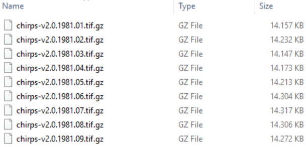

## Downloading CHIRPSv2

In case that the download is not working and you get a message saying:

```
Timeout of 60 seconds was reached
```

You can use the *getOption* function to see the timeout set in R and change it with the *options* function.

```r
getOption('timeout')
## [1] 60
options(timeout = 1000)
```

## Downloading CHIRPSv2

**Step 12:** Uncompress (unzip) the files.

```r
mapply(gunzip, list.files(output, pattern = ".gz", full.names = TRUE))
```

Note that the default setting for the gunzip function will remove the zipped file after the output file has been fully created.

# Packages in R

## Packages in R

There are more than 10,000 R packages published on [CRAN](https://cran.r-project.org/), so how do you know which ones to choose for your particular needs? We have already shown you the most common ones needed for the type of work that we often do:

- Work with shapefiles (sf, terra)
- Work with rasters (terra)
- Work with time series and hydrology (hydroGOF, hydroTSM)
- Visualise data (plotrix, maps, plotKML)
- Download products (RCurl, R.utils, MODIStsp, httr, XML)

## Packages in R

If you want to do something in R that can’t be achieved with the packages we have already shown you, start with a Google search and see whether you need to use a function from a different package.

- Simply use *install.packages* to install any package that is needed and then *library* to load it.